# Ex2: Economy

- Cho dữ liệu economy.xlsx. Bộ dữ liệu chứa thông tin về các tỷ lệ Interest_Rate, Unemployment_Rate và Stock_Index_Price theo thời gian (năm, tháng). Người ta dự đoán Stock_Index_Price dựa trên Interest_Rate, hoặc Unemployment_Rate hoặc cả 2. ### Yêu cầu:
- Đọc dữ liệu, tiền xử lý dữ liệu, tổng quan ban đầu về dữ liệu. ### 1. Single variable
- Thực hiện Simple Linear Regression để dự đoán Stock_Index_Price từ Interest_Rate, với các đánh giá mô hình: Training vs Testing 80:20, Cross Validation.
- Nhận xét kết quả. Trực quan hóa kết quả.
- Kiểm chứng overfiting, underfitting của model vừa chọn
- Đánh giá mô hình vừa xây dựng: có cần phải cải tiến gì không? Nếu cần thì thay đổi mô hình.
- Nhận xét kết quả. Trực quan hóa kết quả với mô hình mới thay đổi. So sánh với mô hình ban đầu. Mô hình sau có tốt hơn không? Quyết định chọn mô hình nào? Lý do? ### 2. Multiple variables
- Thực hiện Multiple Linear Resgression để dự đoán Stock_Index_Price từ Interest_Rate, Unemployment_Rate. với các đánh giá mô hình: Training vs Testing 80:20, Cross Validation.
- Nhận xét kết quả. Trực quan hóa kết quả.
- Kiểm chứng overfiting, underfitting của model vừa chọn
- Đánh giá mô hình vừa xây dựng: có cần phải cải tiến gì không? Nếu cần thì thay đổi mô hình.
- Nhận xét kết quả. Trực quan hóa kết quả với mô hình mới thay đổi. So sánh với mô hình ban đầu. Mô hình sau có tốt hơn không? Quyết định chọn mô hình nào? Lý do?

```python
import pandas as pd
import numpy as np
import matplotlib.pyplot as plt
import seaborn as sns
```

```python
def DistributionPlot(RedFunction, BlueFunction, RedName, BlueName, Title):
    ax1 = sns.distplot(RedFunction, hist=False, color="r", label=RedName)
    ax2 = sns.distplot(BlueFunction, hist=False, color="b", label=BlueName, ax=ax1)

    plt.title(Title)
    plt.xlabel('Stock Index Price')
    plt.ylabel('Proportion')
```

```python
def PollyPlot(xtrain, xtest, y_train, y_test, lr,poly_transform):
    width = 12
    height = 10
    plt.figure(figsize=(width, height))

    #training data
    #testing data
    #lr: linear regression object
    #poly_transform:  polynomial transformation object

    xmax=max([xtrain.values.max(), xtest.values.max()])
    xmin=min([xtrain.values.min(), xtest.values.min()])
    x=np.arange(xmin, xmax, 0.1)

    plt.plot(xtrain, y_train, 'ro', label='Training Data')
    plt.plot(xtest, y_test, 'go', label='Test Data')
    plt.plot(x, lr.predict(poly_transform.fit_transform(x.reshape(-1, 1))), label='Predicted Function')
    plt.ylim([0, 2000])# nho chinh lai ylim cho phu hop voi tung bai toan
    plt.ylabel('Stock Index Price')
    plt.legend()
```

```python
# Đọc dữ liệu, tiền xử lý dữ liệu, tổng quan ban đầu về dữ liệu
data = pd.read_excel("economy.xlsx")
```

```python
data.head()
```

|  | Year | Month | Interest_Rate | Unemployment_Rate | Stock_Index_Price |
| --- | --- | --- | --- | --- | --- |
| 0 | 2017 | 12 | 2.75 | 5.3 | 1464 |
| 1 | 2017 | 11 | 2.50 | 5.3 | 1394 |
| 2 | 2017 | 10 | 2.50 | 5.3 | 1357 |
| 3 | 2017 | 9 | 2.50 | 5.3 | 1293 |
| 4 | 2017 | 8 | 2.50 | 5.4 | 1256 |

```python
data.info()
```

```
<class 'pandas.core.frame.DataFrame'>
RangeIndex: 24 entries, 0 to 23
Data columns (total 5 columns):
Year                 24 non-null int64
Month                24 non-null int64
Interest_Rate        24 non-null float64
Unemployment_Rate    24 non-null float64
Stock_Index_Price    24 non-null int64
dtypes: float64(2), int64(3)
memory usage: 1.0 KB
```

```python
data.describe()
```

|  | Year | Month | Interest_Rate | Unemployment_Rate | Stock_Index_Price |
| --- | --- | --- | --- | --- | --- |
| count | 24.000000 | 24.000000 | 24.000000 | 24.00000 | 24.000000 |
| mean | 2016.500000 | 6.500000 | 2.072917 | 5.77500 | 1070.083333 |
| std | 0.510754 | 3.526299 | 0.349527 | 0.33002 | 210.735341 |
| min | 2016.000000 | 1.000000 | 1.750000 | 5.30000 | 704.000000 |
| 25% | 2016.000000 | 3.750000 | 1.750000 | 5.50000 | 928.250000 |
| 50% | 2016.500000 | 6.500000 | 2.000000 | 5.85000 | 1061.000000 |
| 75% | 2017.000000 | 9.250000 | 2.500000 | 6.10000 | 1239.000000 |
| max | 2017.000000 | 12.000000 | 2.750000 | 6.20000 | 1464.000000 |

```python
# không có dữ liệu null
```

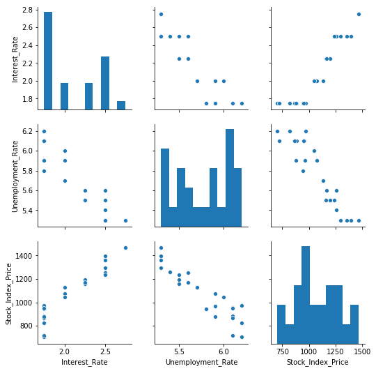

```python
sns.pairplot(data[["Interest_Rate", "Unemployment_Rate", "Stock_Index_Price"]])
plt.show()
```

```python
# Nhận xét: Stock Index Price gần như tương quan thuận  với Interest Rate
# và gần như tương quan nghịch với Unemployment Rate
```